# Tidymodels

James Duncan, STAT 215A Fall 2020

November 13, 2020

## Introducing `tidymodels`

*Note: much of this tutorial is based on examples in [Tidy Modeling with R](https://www.tmwr.org/) (currently unfinished). Another great resource is [Rebecca Barter’s tutorial](http://www.rebeccabarter.com/blog/2020-03-25_machine_learning/).*

The R package `tidymodels` provides utilities for machine learning and creates a unified interface to the vast ecosystem of machine learning packages written in R. It is the successor package to `caret` and is written in part by the same author, Max Kuhn. In fact, `tidymodels` itself is really an ecosystem that includes the following packages:

- [`rsample`](https://rsample.tidymodels.org/): data resampling and splitting
- [`recipes`](https://recipes.tidymodels.org/): design matrix specification
- [`parsnip`](https://parsnip.tidymodels.org/): ML model specification
- [`tune`](https://tune.tidymodels.org/): parameter tuning
- [`yardstick`](https://yardstick.tidymodels.org/): model evaluation

Let’s start by installing the `tidymodels` and `modeldata` (for the example dataset we will use) packages:

```r
install.packages("tidymodels")
install.packages("modeldata")
library(tidymodels)
```

Let’s load in the Ames housing data set that we saw in lecture earlier this semester:

```r
data(ames, package = "modeldata")
```

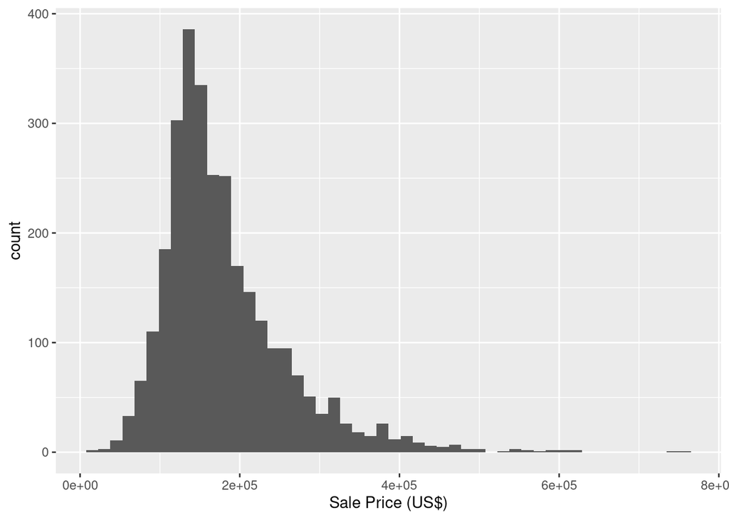

```r
ggplot(ames, aes(x = Sale_Price)) +
  geom_histogram(bins = 50) +
  xlab("Sale Price (US$)")
```

Our models will probably work better if we apply a transformation that reduces the amount of skew, so let’s do that now. We’ll see later how we can create reusable `recipes` to do transformations on our predictors, but typically we will want to manually transform the outcome.

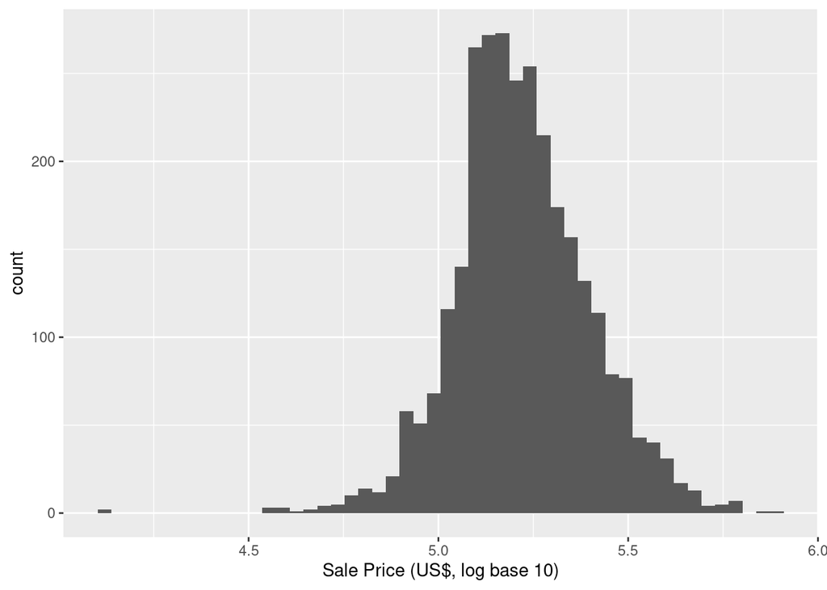

```r
ames <- ames %>%
  mutate(Sale_Price = log10(Sale_Price))

ggplot(ames, aes(x = Sale_Price)) +
  geom_histogram(bins = 50) +
  xlab("Sale Price (US$, log base 10)")
```

## Sample splitting

The `rsample` package provides utilities for working with “resamples” of the data, which it defines as two-way splits of a dataset. It uses two main abstractions for working with these sample splits:

1. `rsplit`: represents an individual two-way split of the dataset into “analysis” and “assessment” data. For example, this could be one of the train/validation splits in 10-fold cross-validation, i.e. 90% of the data as training and 10% as validation. In bootstrap, it would be the data that was sampled during the sampling with replacement, and the remainder of the data that wasn’t sampled.
2. `rset`: represents a set of two-way splits. An `rset` is a `tibble` (if you’re not familiar with `tibbles`, just think `data.frame`). For example, an `rset` could hold all 10 of the 10-fold cross validation splits, or it may hold multiple bootstrap samples.

The `initial_split()` function creates a training and test set. Use `initial_split()` to create an 80/20 division of the data where you stratify on the outcome `Sale_Price` to ensure a balanced split:

```r
# to make the split reproducible, we must set a seed
set.seed(215)

# you may want to take a look at the documentation for initial_split()
# ?initial_split

# create a train-test split, stratified by Sale_Price
```

We can access the training set using the function `training()` and the test set via `testing()`. Extract the training and test sets into variables called `ames_train` and `ames_test`:

```r
# ames_train

# ames_test
```

We can further split the training set into training and validation using the function `validation_split()`. Extract the training set using `training()` and apply `validation_split()` to it. Don’t forget to stratify by `Sale_Price`:

```r
# create a validation split
```

**Note**: You may notice that `validation_split()` returns an `rset` rather than an `rsplit` as in the case of `initial_split()`.

Finally, we might also want to do some parameter tuning using cross validation, so we can use `vfold_cv()` on the “analysis” portion of the validation split. Do that now. **Hint:** Extract the `rsplit` object from the `splits` column of the validation `rset`, and use `training()` and `testing()` on it.

```r
# get the validation split from the rset from validation_split()

# create a vfold_cv set from the training data
```

## Recipes

Now that our sample splits are ready, lets prepare for model fitting by pre-processing the data. The `recipes` package allows us to do feature engineering and preprocessing tasks in a unified way across our models. It also allows us to decouple the specification of the variables we want to use from the preprocessing steps we will apply to those variables. For example, take the following simple formula:

```
Sale_Price ~ Neighborhood + log10(Gr_Liv_Area) + Year_Built + Bldg_Type
```

Using `recipes`, we can create an object to represent this formula as:

```r
simple_ames <-
  recipe(Sale_Price ~ Neighborhood + Gr_Liv_Area + Year_Built + Bldg_Type,
         data = ames_train) %>%
  step_log(Gr_Liv_Area, base = 10) %>% # log10 transform the Gr_Liv_Area variable
  step_dummy(all_nominal()) # binarize all of the categorical variables
```

This separates the variable selection from the variable transformations: in this case, taking the log of `Gr_Liv_Area` (area of the living room) and applying a binary encoding to all of the columns that have factor or character types. Moreover, we can select variables using `dplyr`-like syntax.

Say that we want to add `Exter_Cond`, the exterior condition of the house, as one of our predictors. This is an ordinal variable with values (from worst to best) “Poor”, “Fair”, “Typical”, “Good”, and “Excellent”. Let’s look how many observations there are in each level:

| Exter_Cond | n |
| --- | --- |
| Excellent | 12 |
| Fair | 67 |
| Good | 299 |
| Poor | 3 |
| Typical | 2549 |

There are very few “Excellent” houses and even fewer “Poor” houses, but we still think this is an important variable, so lets apply a transformation to replace `Exter_Cond` with the levels “Low” (“Poor” and “Fair”), “Average” (“Typical”), and “High” (“Good” and “Excellent”). We can use `step_mutate()` which works just like `dplyr`’s `mutate()` function:

```r
# same as before, but now Exter_Cond is included
# and wait to binarize until after we remake Exter_Cond
simple_ames <-
  recipe(Sale_Price ~
           Neighborhood + Gr_Liv_Area + Year_Built + Bldg_Type + Exter_Cond,
         data = ames) %>%
  step_log(Gr_Liv_Area, base = 10) # log10 transform the Gr_Liv_Area variable

# Add a step to the remake Exter_Cond variable. Be sure that the variable is a
# factor so it gets converted to a dummy variable by step_dummy.
simple_ames <- simple_ames %>%
  step_mutate(
    Exter_Cond = factor(if_else(
      Exter_Cond %in% c("Poor", "Fair"), "Low",
      if_else(
        Exter_Cond %in% c("Good", "Excellent"), "High",
        "Average" # corresponds to Typical in Exter_Cond
      )
    ))
  ) %>%
  step_dummy(all_nominal()) # don't forget to binarize all of the categorical variables
simple_ames
```

```
## Data Recipe
##
## Inputs:
##
##       role #variables
##    outcome          1
##  predictor          5
##
## Operations:
##
## Log transformation on Gr_Liv_Area
## Variable mutation for Exter_Cond
## Dummy variables from all_nominal()
```

**Note**: Feel free to use a more complicated formula. You can learn more about the data [here](http://jse.amstat.org/v19n3/decock/DataDocumentation.txt).

At this point, we haven’t actually done anything to the data yet; we’re simply creating a reusable specification of how the data should be prepared. To apply these steps and actually calculate statistics from the training data, use the `prep()` function:

```r
# prepare pre-processing statistics
simple_ames <- prep(simple_ames, training = ames_train, retain = TRUE)
```

The `prep()` function calculates and saves statistics on the training data. We’ve used the argument `retain = TRUE` so that the pre-processed training data is retained and we don’t have to redo the computation later on. The `bake()` function (if the cooking analogy wasn’t already painfully obvious I’m sure it is now) can be used to apply pre-processing steps to new data (or get the pre-processed training data) via `new_data` argument. For example:

```r
# time to bake the recipe now that the ingredients are prepared
# this returns the pre-processed validation data
bake(simple_ames, new_data = ames_validate)
```

To make the point of all of this a bit more clear, consider the step `step_normalize()`. When used in a recipe and applied to some training data using `prep()`, this step calculates and saves the means and SDs of the continuous predictors in the data. Then, when the recipe is used again on assessment data via `bake()`, the continuous variables in this new data are centered and scaled *using the means and SDs calculated on the training data*.

Luckily, as we will see later on, we don’t actually have to manually call `prep()` and `bake()` at every step of our analysis. Instead, they will be called for us under the hood by higher level model-fitting functions from the `parsnip` package.

## Modeling

### Unified modeling via `parsnip`

The `parsnip` package helps to create a unified interface to the many modeling packages and functions that are available in R. For example, the `glmnet()` function expects arguments `x` and `y` where `x` is a design matrix (not at a `data.frame`!) and `y` is a vector of responses, which results in a very different interface for linear models with and without regularization:

```r
# generate some predictors
data_matrix <- matrix(rnorm(15000), ncol = 100)
colnames(data_matrix) <- paste0("x", 1:100)

# generate a sparse response
beta <- c(3, 3, -3, 0, -3, 0, 3, rep(0, 93))
y <- rnorm(150, data_matrix %*% beta)

# create a data.frame with response and predictors
data_df <- cbind(as.data.frame(cbind(y, data_matrix)))

# linear model, no regularization
# handy formula syntax y ~ .
# data argument must be a data.frame
lm(y ~ ., data = data_df)

# linear model with l1 penalty
# x must be a matrix
# can't use a formula
glmnet(x = data_matrix, y = y)
```

Using `parsnip`, this becomes a bit nicer:

```r
lm_model <- linear_reg() %>% set_engine("lm")
lm_model
```

```
## Linear Regression Model Specification (regression)
##
## Computational engine: lm
```

```r
lm_l1_model <- linear_reg() %>% set_engine("glmnet")
lm_l1_model
```

```
## Linear Regression Model Specification (regression)
##
## Computational engine: glmnet
```

We use `set_engine()` to tell `parsnip` what package to use when we fit the model. To see what engines are available use `show_engines("model_type")`; in this case, `show_engines("linear_reg")`. To see what the equivalent call would be in the original package’s syntax, use `translate()`:

```r
lm_l1_model %>% translate()
```

```
## Linear Regression Model Specification (regression)
##
## Computational engine: glmnet
##
## Model fit template:
## glmnet::glmnet(x = missing_arg(), y = missing_arg(), weights = missing_arg(),
##     family = "gaussian")
```

The `x` and `y` variables are both `missing_arg()` because we haven’t actually told `parsnip` what data to use. To do so, we can use the `fit()` function:

```r
# you can use the formula syntax
lm_l1_model %>% fit(y ~ ., data = data_df)

# or you can use the x and y syntax
lm_l1_model %>% fit_xy(x = data_matrix, y = y)

# and the xy syntax works fine with a data.frame
lm_l1_model %>% fit_xy(x = data_df %>% select(starts_with("x")), y = y)
```

So far we’ve seen how we specify the type of model using functions like `linear_reg()` and choose the specific implementation via `set_engine()`. Some models, however, are flexible in the types of outcomes they can estimate, so in those cases we can use `set_mode()` to specify our outcome type:

```r
# fit a random forest to our toy data
rand_forest() %>% # the model type and hyperparameters
  set_engine("ranger") %>% # the backend
  set_mode("regression") %>% # the outcome type
  fit(y ~ ., data = data_df)
```

```
## parsnip model object
##
## Fit time:  170ms
## Ranger result
##
## Call:
##  ranger::ranger(x = maybe_data_frame(x), y = y, num.threads = 1,      verbose = FALSE, seed = sample.int(10^5, 1))
##
## Type:                             Regression
## Number of trees:                  500
## Sample size:                      150
## Number of independent variables:  100
## Mtry:                             10
## Target node size:                 5
## Variable importance mode:         none
## Splitrule:                        variance
## OOB prediction error (MSE):       35.76098
## R squared (OOB):                  0.3264005
```

The `parsnip` package also helps provide some consistency in model arguments as well as consistency in the modeling interface. You can learn more in Chapter 7 of the [Tidy Modeling with R](https://www.tmwr.org/models.html) book. Note that some of the models supported within the `parsnip` modeling framework are included in other packages to prevent the `parsnip` package itself from becoming too bloated. To learn more about what models are supported by `parsnip`, as well as the arguments and available engines, you can use its [model explorer](https://www.tidymodels.org/find/parsnip/).

### Putting it together with `workflows`

We can use `parsnip` to fit individual models, but the real power of `tidymodels` becomes apparent when we chain together the sample splitting, data pre-processing, and modeling into one cohesive pipeline. The `workflows` package allows us to do that. Consider the example below:

```r
lm_base_workflow <- workflow() %>%
  # if you don't have any preprocessing, you can just use a simple formula here
  add_formula(y ~ .)

lm_workflow <- lm_base_workflow %>%
  add_model(lm_model)

lm_l1_workflow <- lm_base_workflow %>%
  add_model(lm_l1_model)
```

To add a recipe instead of a formula, use `add_recipe()`.

Let’s return to the Ames data. Create a workflow that has:

1. A random forest model which uses the `ranger` package as its engine. You should modify one of the default arguments.
2. A recipe like `simple_ames` that additionally puts all of the `Neighborhood`s that have less than 1% of the observations into an “other” category. (There may be a better choice than `step_mutate()` to do this. Check the [`recipes` function reference page](https://recipes.tidymodels.org/reference/index.html). Also, do we need dummy variables for random forest?)

Also create a workflow with a similar recipe but replace the random forest with a linear model.

```r
# create a random forest workflow

# create a linear model workflow
```

## Model tuning

### Evaluating models with `yardstick`

Before continuing with the Ames data, let’s return to the toy linear regression example to see how we can tune and evaluate our models. To use the metrics in `yardstick` we first need to put our predictions and the corresponding observed values into a `data.frame`.

```r
# split the toy data into training and test sets using rsample
data_split <- initial_split(data_df, prop = 0.8)
data_train <- training(data_split)
data_test <- testing(data_split)

# create a recipe to normalize the covariates
lm_recipe <- recipe(y ~ ., data = data_train) %>%
  # normalize all numeric predictors, but not the outcome
  step_normalize(all_numeric(), -y)

lm_workflow <- lm_workflow %>%
  # we have to remove the formula
  remove_formula() %>%
  # before we can add the recipe
  add_recipe(lm_recipe)

lm_l1_workflow <- lm_l1_workflow %>%
  remove_formula() %>%
  add_recipe(lm_recipe)

# predict
lm_fit <- lm_workflow %>% fit(data = data_train)
lm_l1_fit <- lm_l1_workflow %>% fit(data = data_train)

# create the data.frame of predictions and observed values
lm_test_res <- bind_cols(
  # get the lm predictions
  predict( # this returns a tibble with a .pred column with the predictions
    lm_fit,
    new_data = data_test %>% select(-y)
  ) %>%
    rename(lm_pred = .pred), # rename the .pred column
  # get the glmnet predictions
  predict(
    lm_l1_fit,
    # the penalty is required for the glmnet engine
    # we arbitrarily choose lambda = 0.5
    # normally one would use CV to choose
    penalty = 0.5,
    new_data = data_test %>% select(-y)
  ) %>%
    rename(lm_l1_pred = .pred),
  # the corresponding observed values
  data_test %>% select(y)
)
```

Now that we have the predictions we can use `rmse` to get the root mean-squared error:

```r
# rmse for lm
rmse(lm_test_res, truth = y, estimate = lm_pred)
```

```
## # A tibble: 1 x 3
##   .metric .estimator .estimate
##   <chr>   <chr>          <dbl>
## 1 rmse    standard        1.90
```

```r
# rmse for lasso
rmse(lm_test_res, truth = y, estimate = lm_l1_pred)
```

```
## # A tibble: 1 x 3
##   .metric .estimator .estimate
##   <chr>   <chr>          <dbl>
## 1 rmse    standard        1.52
```

If there were multiple metrics we cared about, we could group them using `metric_set()` which returns a function that we can use just like the individual metric functions:

```r
# create the metric set
lm_metrics <- metric_set(rmse, rsq, mae)

# all the metrics for lm
lm_metrics(lm_test_res, truth = y, estimate = lm_pred)
```

```
## # A tibble: 3 x 3
##   .metric .estimator .estimate
##   <chr>   <chr>          <dbl>
## 1 rmse    standard       1.90
## 2 rsq     standard       0.954
## 3 mae     standard       1.61
```

```r
# all the metrics for lasso
lm_metrics(lm_test_res, truth = y, estimate = lm_l1_pred)
```

```
## # A tibble: 3 x 3
##   .metric .estimator .estimate
##   <chr>   <chr>          <dbl>
## 1 rmse    standard       1.52
## 2 rsq     standard       0.988
## 3 mae     standard       1.22
```

### Hyperparameter Tuning

Often when adding regularization model, we use cross-validation to choose the amount of regularization. In `glmnet`, this would be done using the function `cv.glmnet()`. For our toy problem, this results in the following:

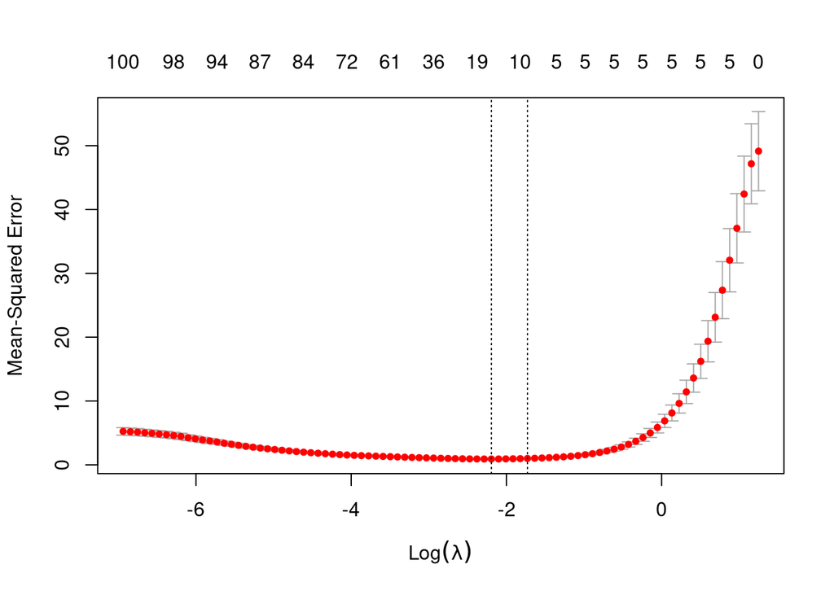

Let’s produce the same thing using `tidymodels`. We’ll instead use `tune_grid()` from the `tune` package along with a `vfold_cv` sample split. Below we create the `vfold_cv` sample split for the `data_train` data frame and tune the `penalty` parameter for regularized regression:

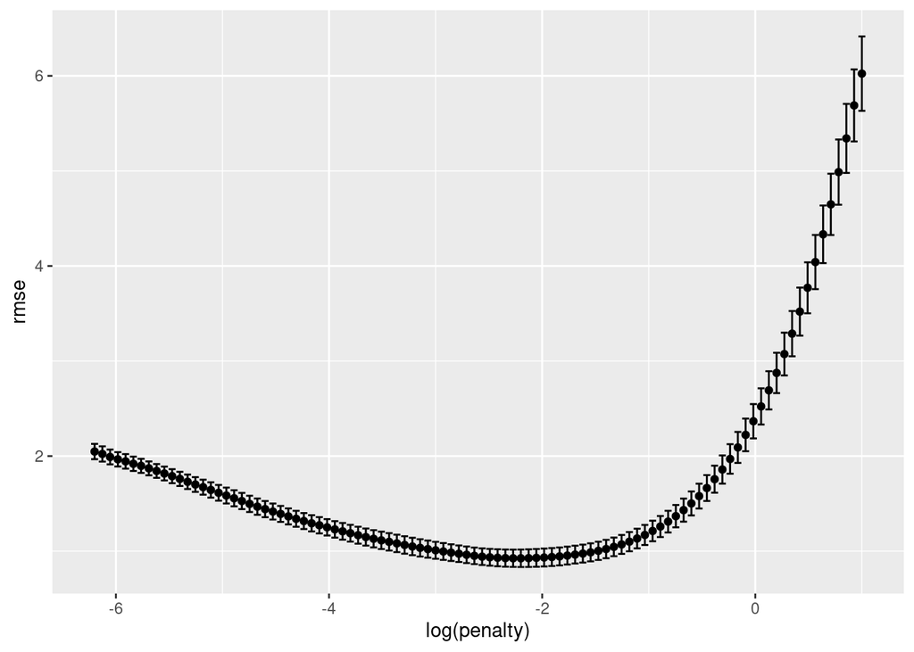

```r
# split the data into 10 cv folds
cv_data <- vfold_cv(data_train)

# create the hyperparameter grid
penalty_grid <- expand.grid(penalty = exp(seq(-6.2, 1, length.out = 100)))

# add a normalization step
lm_l1_recipe <- recipe(y ~ ., data = data_train) %>%
  step_normalize(all_numeric(), -y)

# we need to use tune() as a placeholder for the hyperparameter so that the
# model knows it will be tuned
tuning_lm_l1_model <- lm_l1_model %>%
  set_args(penalty = tune())

# tune the penalty parameter using CV
lm_l1_cv_tuned <- workflow()  %>%
  add_recipe(lm_l1_recipe) %>%
  add_model(tuning_lm_l1_model) %>%
  tune_grid(resamples = cv_data, grid = penalty_grid,
            metrics = metric_set(rmse))

# collect_metrics() is a handy helper to output the results
lm_l1_metrics <- lm_l1_cv_tuned %>%
  collect_metrics()

# plot the cv error as a function of the penalty
lm_l1_metrics %>%
  ggplot(aes(x = log(penalty), y = mean)) +
  geom_point() +
  geom_errorbar(aes(ymin = mean - std_err, ymax = mean + std_err)) +
  labs(y = "rmse")
```

The y-axis is root-mean-square error and the results are not quite the same as `glmnet`’s, but this is to be expected since our CV folds will not be the same as those chosen by `glmnet`. Now we can use our best penalty and estimate the `rmse` for the test set:

```r
penalty <- min(lm_l1_metrics$mean)

tuned_lm_l1_model <- lm_l1_model %>%
  set_args(penalty = penalty)

# refit to the training set
tuned_lm_l1_model_fit <- workflow()  %>%
  add_recipe(lm_l1_recipe) %>%
  add_model(tuned_lm_l1_model) %>%
  fit(data = data_train)

# recall that the result of predict is a tibble
lm_l1_tuned_test_res <- bind_cols(
  predict(
    tuned_lm_l1_model_fit,
    new_data = data_test %>% select(-y)
  ),
  data_test %>% select(y)
)

lm_metrics(lm_l1_tuned_test_res, truth = y, estimate = .pred)
```

```
## # A tibble: 3 x 3
##   .metric .estimator .estimate
##   <chr>   <chr>          <dbl>
## 1 rmse    standard       2.49
## 2 rsq     standard       0.986
## 3 mae     standard       1.96
```

## Final Exercise: Ames housing data analysis

Now you have all of the tools you need to undertake a full analysis of the Ames housing data set. Use what you’ve learned to:

1. Fit two or more models on the Ames housing data using the CV portion of the training set. You should tune a hyperparameter for at least one of the models.
2. Choose the better of your two models on the validation set (**Hint**: use the function `fit_resamples()` from the `tune` package when working with the result of `validation_split()`).
3. Evaluate your best model on the test set and report the final estimate of future error.

```r
# write your code here
```

## References

- [Tidy Modeling with R](https://www.tmwr.org/) (book co-authored by Max Kuhn and Julie Silge)
- [Tidymodels: tidy machine learning in R](http://www.rebeccabarter.com/blog/2020-03-25_machine_learning/) (another good tutorial to check out by Rebecca Barter)
- [rsample “Basics” vignette](https://cran.r-project.org/web/packages/rsample/vignettes/Basics.html)